# 备砖： 用R进行数据管理1

2018年

## 内容提纲

- tibble数据框
- 变量管理:使用`dplyr`
  - `filter()`: 筛选案例 | `sample_n()` / `sample_frac()`: 随机选择案例
  - `select()`: 筛选变量 | `rename()`: 变量重命名
  - `fct_recode`:recode变量 | `mutate()`: 增加新变量
  - `summarise()` 汇总统计 | `group_by()` 分组
  - `arrange()`: 案例排序
- 字符串处理
- 日期处理

## tibbles 数据框

data.frame基础做了针对性的改进。无行名，不修改变量类型，灵活列印,索引方便等等。继承了data.frame的其他多数特性。

```r
library(tidyverse)
as_tibble(iris)
```

```
## # A tibble: 150 x 5
##    Sepal.Length Sepal.Width Petal.Length Petal.Width Species
##           <dbl>       <dbl>        <dbl>       <dbl> <fct>
##  1         5.10        3.50         1.40       0.200 setosa
##  2         4.90        3.00         1.40       0.200 setosa
##  3         4.70        3.20         1.30       0.200 setosa
##  4         4.60        3.10         1.50       0.200 setosa
##  5         5.00        3.60         1.40       0.200 setosa
##  6         5.40        3.90         1.70       0.400 setosa
##  7         4.60        3.40         1.40       0.300 setosa
##  8         5.00        3.40         1.50       0.200 setosa
##  9         4.40        2.90         1.40       0.200 setosa
## 10         4.90        3.10         1.50       0.100 setosa
## # ... with 140 more rows
```

## tibble数据

手工创建数据集

```r
df <- tibble(
  x = 1:5,
  y = 1,
  z = x ^ 2 + y
)
df %>% .$x  #  或者.[["x"]]
```

```
## [1] 1 2 3 4 5
```

```r
df
```

```
## # A tibble: 5 x 3
##       x     y     z
##   <int> <dbl> <dbl>
## 1     1    1.    2.
## 2     2    1.    5.
## 3     3    1.   10.
## 4     4    1.   17.
## 5     5    1.   26.
```

## tibble数据集

tribble方便小块数据输入

```r
tribble(
  ~x, ~y, ~z,

  "a", 2, 3.6,
  "b", 1, 8.5
)
```

```
## # A tibble: 2 x 3
##   x         y     z
##   <chr> <dbl> <dbl>
## 1 a        2.  3.60
## 2 b        1.  8.50
```

## 使用`dplyr` 处理变量

## `dplyr` 规则

- 第一个参数是数据框
- 返回的是数据框

## 筛选个案 `filter()`

- 选择案例（行）
- 能同时设定多个筛选条件

```r
# 读入数据
bike <- read_delim("../data/nc_bike_crash.csv", ";",
    escape_double = FALSE, trim_ws = TRUE)
```

## 筛选个案 `filter()`

选出Durham县发生的与自行车相关的交通事故 注意：== | & > < >= <= != 等比较符号。

```r
bike %>%
  filter(County == "Durham")
```

```
## # A tibble: 253 x 54
##      FID OBJECTID AmbulanceR BikeAge_Gr Bike_Age Bike_Alc_D Bike_Dir
##    <int>    <int> <chr>      <chr>         <int> <chr>      <chr>
##  1    18       19 No         <NA>              6 No         Not Applicable
##  2    53       54 Yes        50-59            52 No         With Traffic
##  3    56       57 Yes        16-19            18 No         <NA>
##  4   209      210 No         16-19            16 No         Facing Traffic
##  5   228      229 Yes        40-49            40 No         With Traffic
##  6   620      621 Yes        50-59            55 No         With Traffic
##  7   667      668 Yes        60-69            61 No         Not Applicable
##  8   458      459 Yes        60-69            62 No         With Traffic
##  9   576      577 No         40-49            49 No         With Traffic
## 10   618      619 No         20-24            23 No         With Traffic
## # ... with 243 more rows, and 47 more variables: Bike_Injur <chr>,
## #   Bike_Pos <chr>, Bike_Race <chr>, Bike_Sex <chr>, City <chr>,
## #   County <chr>, CrashAlcoh <chr>, CrashDay <chr>, Crash_Date <date>,
## #   Crash_Grp <chr>, Crash_Hour <int>, Crash_Loc <chr>, Crash_Mont <chr>,
## #   Crash_Time <dttm>, Crash_Type <chr>, Crash_Ty_1 <int>,
## #   Crash_Year <int>, Crsh_Sevri <chr>, Developmen <chr>,
## #   DrvrAge_Gr <chr>, Drvr_Age <int>, Drvr_Alc_D <chr>, Drvr_EstSp <chr>,
## #   Drvr_Injur <chr>, Drvr_Race <chr>, Drvr_Sex <chr>, Drvr_VehTy <chr>,
## #   ExcsSpdInd <chr>, Hit_Run <chr>, Light_Cond <chr>, Locality <chr>,
## #   Num_Lanes <chr>, Num_Units <int>, Rd_Charact <chr>, Rd_Class <chr>,
## #   Rd_Conditi <chr>, Rd_Config <chr>, Rd_Defects <chr>, Rd_Feature <chr>,
## #   Rd_Surface <chr>, Region <chr>, Rural_Urba <chr>, Speed_Limi <chr>,
## #   Traff_Cntr <chr>, Weather <chr>, Workzone_I <chr>, Location <chr>
```

## 筛选个案`filter()`

选出Durham县且车龄 < 10 的案例

```r
bike %>%
  filter(County == "Durham", Bike_Age < 10)
```

```
## # A tibble: 20 x 54
##      FID OBJECTID AmbulanceR BikeAge_Gr Bike_Age Bike_Alc_D Bike_Dir
##    <int>    <int> <chr>      <chr>         <int> <chr>      <chr>
##  1    18       19 No         <NA>              6 No         Not Applicable
##  2    47       48 No         10-Jun            9 No         Not Applicable
##  3   124      125 Yes        10-Jun            8 No         With Traffic
##  4   531      532 Yes        10-Jun            7 No         With Traffic
##  5   704      705 Yes        10-Jun            9 No         Not Applicable
##  6    42       43 No         10-Jun            8 No         With Traffic
##  7   392      393 Yes        0-5               2 No         Not Applicable
##  8   941      942 No         10-Jun            9 No         With Traffic
##  9   436      437 Yes        10-Jun            6 No         Not Applicable
## 10   160      161 Yes        10-Jun            7 No         With Traffic
## 11   273      274 Yes        10-Jun            7 No         Facing Traffic
## 12    78       79 Yes        10-Jun            7 No         With Traffic
## 13   422      423 No         10-Jun            9 No         Not Applicable
## 14   570      571 No         <NA>              0 Missing    Not Applicable
## 15   683      684 Yes        10-Jun            8 No         Not Applicable
## 16    62       63 Yes        10-Jun            7 No         With Traffic
## 17   248      249 No         0-5               4 No         Not Applicable
## 18   306      307 Yes        10-Jun            8 No         With Traffic
## 19   231      232 Yes        10-Jun            8 No         With Traffic
## 20   361      362 Yes        10-Jun            9 No         With Traffic
## # ... with 47 more variables: Bike_Injur <chr>, Bike_Pos <chr>,
## #   Bike_Race <chr>, Bike_Sex <chr>, City <chr>, County <chr>,
## #   CrashAlcoh <chr>, CrashDay <chr>, Crash_Date <date>, Crash_Grp <chr>,
## #   Crash_Hour <int>, Crash_Loc <chr>, Crash_Mont <chr>,
## #   Crash_Time <dttm>, Crash_Type <chr>, Crash_Ty_1 <int>,
## #   Crash_Year <int>, Crsh_Sevri <chr>, Developmen <chr>,
## #   DrvrAge_Gr <chr>, Drvr_Age <int>, Drvr_Alc_D <chr>, Drvr_EstSp <chr>,
## #   Drvr_Injur <chr>, Drvr_Race <chr>, Drvr_Sex <chr>, Drvr_VehTy <chr>,
## #   ExcsSpdInd <chr>, Hit_Run <chr>, Light_Cond <chr>, Locality <chr>,
## #   Num_Lanes <chr>, Num_Units <int>, Rd_Charact <chr>, Rd_Class <chr>,
## #   Rd_Conditi <chr>, Rd_Config <chr>, Rd_Defects <chr>, Rd_Feature <chr>,
## #   Rd_Surface <chr>, Region <chr>, Rural_Urba <chr>, Speed_Limi <chr>,
## #   Traff_Cntr <chr>, Weather <chr>, Workzone_I <chr>, Location <chr>
```

## `slice()` 选择部分案例

头五条

```r
bike %>%
  slice(1:5)
```

```
## # A tibble: 5 x 54
##     FID OBJECTID AmbulanceR BikeAge_Gr Bike_Age Bike_Alc_D Bike_Dir
##   <int>    <int> <chr>      <chr>         <int> <chr>      <chr>
## 1    18       19 No         <NA>              6 No         Not Applicable
## 2    29       30 Yes        50-59            51 No         With Traffic
## 3    33       34 No         <NA>             10 No         With Traffic
## 4    35       36 Yes        16-19            17 No         <NA>
## 5    49       50 No         <NA>              6 No         Facing Traffic
## # ... with 47 more variables: Bike_Injur <chr>, Bike_Pos <chr>,
## #   Bike_Race <chr>, Bike_Sex <chr>, City <chr>, County <chr>,
## #   CrashAlcoh <chr>, CrashDay <chr>, Crash_Date <date>, Crash_Grp <chr>,
## #   Crash_Hour <int>, Crash_Loc <chr>, Crash_Mont <chr>,
## #   Crash_Time <dttm>, Crash_Type <chr>, Crash_Ty_1 <int>,
## #   Crash_Year <int>, Crsh_Sevri <chr>, Developmen <chr>,
## #   DrvrAge_Gr <chr>, Drvr_Age <int>, Drvr_Alc_D <chr>, Drvr_EstSp <chr>,
## #   Drvr_Injur <chr>, Drvr_Race <chr>, Drvr_Sex <chr>, Drvr_VehTy <chr>,
## #   ExcsSpdInd <chr>, Hit_Run <chr>, Light_Cond <chr>, Locality <chr>,
## #   Num_Lanes <chr>, Num_Units <int>, Rd_Charact <chr>, Rd_Class <chr>,
## #   Rd_Conditi <chr>, Rd_Config <chr>, Rd_Defects <chr>, Rd_Feature <chr>,
## #   Rd_Surface <chr>, Region <chr>, Rural_Urba <chr>, Speed_Limi <chr>,
## #   Traff_Cntr <chr>, Weather <chr>, Workzone_I <chr>, Location <chr>
```

```r
#等价于bike %>% head(5)
```

## `slice()` 选择部分案例

最后五条

```r
last_row <- nrow(bike)
bike %>%
  slice((last_row-4):last_row)
```

```
## # A tibble: 5 x 54
##     FID OBJECTID AmbulanceR BikeAge_Gr Bike_Age Bike_Alc_D Bike_Dir
##   <int>    <int> <chr>      <chr>         <int> <chr>      <chr>
## 1   460      461 Yes        10-Jun            7 No         Not Applicable
## 2   474      475 Yes        50-59            50 No         With Traffic
## 3   479      480 Yes        16-19            16 No         Not Applicable
## 4   487      488 No         40-49            47 Yes        With Traffic
## 5   488      489 Yes        30-39            35 No         Facing Traffic
## # ... with 47 more variables: Bike_Injur <chr>, Bike_Pos <chr>,
## #   Bike_Race <chr>, Bike_Sex <chr>, City <chr>, County <chr>,
## #   CrashAlcoh <chr>, CrashDay <chr>, Crash_Date <date>, Crash_Grp <chr>,
## #   Crash_Hour <int>, Crash_Loc <chr>, Crash_Mont <chr>,
## #   Crash_Time <dttm>, Crash_Type <chr>, Crash_Ty_1 <int>,
## #   Crash_Year <int>, Crsh_Sevri <chr>, Developmen <chr>,
## #   DrvrAge_Gr <chr>, Drvr_Age <int>, Drvr_Alc_D <chr>, Drvr_EstSp <chr>,
## #   Drvr_Injur <chr>, Drvr_Race <chr>, Drvr_Sex <chr>, Drvr_VehTy <chr>,
## #   ExcsSpdInd <chr>, Hit_Run <chr>, Light_Cond <chr>, Locality <chr>,
## #   Num_Lanes <chr>, Num_Units <int>, Rd_Charact <chr>, Rd_Class <chr>,
## #   Rd_Conditi <chr>, Rd_Config <chr>, Rd_Defects <chr>, Rd_Feature <chr>,
## #   Rd_Surface <chr>, Region <chr>, Rural_Urba <chr>, Speed_Limi <chr>,
## #   Traff_Cntr <chr>, Weather <chr>, Workzone_I <chr>, Location <chr>
```

```r
# 等价于bike %>% tail(5)
```

## `sample_n()` or `sample_frac()`随机挑选案例

- `sample_n()`: 随机选5个案例

```r
bike_n5 <- bike %>%
  sample_n(5, replace = FALSE)
dim(bike_n5)
```

```
## [1]  5 54
```

- `sample_frac()`: 随机选20%案例

```r
bike_perc20 <-bike %>%
  sample_frac(0.2, replace = FALSE)
dim(bike_perc20)
```

```
## [1] 1143   54
```

## 选择变量`select()`

```r
bike %>%
  select(Crash_Loc, Hit_Run) %>%
  table()
```

```
##                       Hit_Run
## Crash_Loc                No  Yes
##   .                       4    0
##   Intersection         2223  275
##   Intersection-Related  252   42
##   Location                3    7
##   Non-Intersection     2213  462
##   Non-Roadway           205   30
```

## 选择变量

dplyr中的summarize默认summ该数据框中的变量

```r
out <- bike %>%
summarize(
    min = min(Bike_Age ,na.rm = TRUE),
    q1 = quantile(Bike_Age ,0.25, na.rm = TRUE),
    median = quantile(Bike_Age ,0.5, na.rm = TRUE),
    q3 = quantile(Bike_Age,0.75, na.rm = TRUE),
    max = max(Bike_Age,na.rm = TRUE),
    mean = mean(Bike_Age ,na.rm = TRUE),
    sd = sd(Bike_Age,na.rm = TRUE),
    missing = sum(is.na(Bike_Age))
  )
knitr::kable(out)
```

| min | q1 | median | q3 | max | mean | sd | missing |
| --- | --- | --- | --- | --- | --- | --- | --- |
| 0 | 16 | 27 | 46 | 69 | 30.68886 | 16.87225 | 130 |

## 筛选变量-删除 `select()`

```r
bike %>%
  select(FID,OBJECTID) %>%
  select(-OBJECTID) %>%
  names()
```

```
## [1] "FID"
```

## 重命名 `rename()`

修改变量名.多个包中都有这个函数。

将`Speed_Limi` 改为`Speed_Limit`:

```r
 bike %>%
  rename(Speed_Limit = Speed_Limi) %>%
  select(starts_with("Speed_")) %>%
  names()
```

```
## [1] "Speed_Limit"
```

## 创建变量`mutate()`

可以自定义非常复杂的函数，而不仅仅是基本算数运算。

```r
bike <- bike %>%
  mutate(Bike_birth=Crash_Year - Bike_Age,
         Drvr_birth=Crash_Year - Drvr_Age)
```

## recode因子变量

查看原取值

```r
bike %>%count(DrvrAge_Gr)
```

```
## # A tibble: 10 x 2
##    DrvrAge_Gr     n
##    <chr>      <int>
##  1 0-19         373
##  2 20-24        659
##  3 25-29        531
##  4 30-39        893
##  5 40-49        867
##  6 50-59        731
##  7 60-69        488
##  8 70            78
##  9 70+          337
## 10 <NA>         759
```

将70 和70+ 合并

## recode因子变量

```r
library(forcats)
bike <- bike %>%
  forcats::as_factor(DrvrAge_Gr) %>%  # 实际上可以不要
  mutate(DrvrAge_Gr = fct_recode(DrvrAge_Gr,"70+"="70")) %>%
  mutate(DrvrAge_Gr2 = fct_collapse(DrvrAge_Gr,
                                   "0-19"="0-19",
                                   "20-29"=c("20-24","25-29"),
                                   "30-39"="30-39",
                                   "40-49"="40-49",
                                   "50-59"="50-59",
                                   "60+"=c("60-69","70+")
                                   ))
```

得到的位因子变量。如果原变量是labelled数值，请先转为因子，再recode。

## recode连续变量为分类变量

```r
bike %>%
   mutate(B_agegr=cut(Bike_Age,
                    breaks=c(0,20,40,60,Inf),
                    labels=c("youth","oldyouth","midage","elder"))) %>%
   count(B_agegr)
```

```
## # A tibble: 5 x 2
##   B_agegr      n
##   <fct>    <int>
## 1 youth     2028
## 2 oldyouth  1662
## 3 midage    1632
## 4 elder      225
## 5 <NA>       169
```

ggplot2::cut_number可以等案例数(近似)分割 findInterval也可以分组，左闭区间。cut默认是右闭

## 替换变量：因子变量

```r
# 因子变量只能替换为已定义的取值,不如用recode
bike <- bike %>%
             mutate(DrvrAge_Gr3 =replace(DrvrAge_Gr ,
                                        is.na(DrvrAge_Gr ),
                                        "70+"))
bike %>%count(DrvrAge_Gr3)
```

```
## # A tibble: 8 x 2
##   DrvrAge_Gr3     n
##   <fct>       <int>
## 1 0-19          373
## 2 20-24         659
## 3 25-29         531
## 4 30-39         893
## 5 40-49         867
## 6 50-59         731
## 7 60-69         488
## 8 70+          1174
```

## 替换变量：连续变量

```r
bike <- bike %>%
             mutate(Drvr_Age2=replace(Drvr_Age ,
                                        is.na(Drvr_Age),
                                        mean(Drvr_Age,na.rm=TRUE)))
bike %>%summarise(mean=mean(Drvr_Age2,na.rm=TRUE))
```

```
## # A tibble: 1 x 1
##    mean
##   <dbl>
## 1  39.2
```

## 替换变量：连续变量

```r
bike <- bike %>%
             mutate(DrvrAge_Gr4=if_else(Drvr_Age<30,1,
                                       if_else(Drvr_Age>=60,3,2)))
#bike %>%count(DrvrAge_Gr4)
#等价于
bike <- bike %>%
             mutate(DrvrAge_Gr4=replace(Drvr_Age,Drvr_Age<30,1)) %>%
             mutate(DrvrAge_Gr4=replace(DrvrAge_Gr4,DrvrAge_Gr4>1&DrvrAge_Gr4<60,2)) %>%
             mutate(DrvrAge_Gr4=replace(DrvrAge_Gr4,DrvrAge_Gr4>=60,3))

bike %>%count(DrvrAge_Gr4)
```

```
## # A tibble: 4 x 2
##   DrvrAge_Gr4     n
##         <dbl> <int>
## 1          1.  1563
## 2          2.  2491
## 3          3.   566
## 4         NA   1096
```

## 替换变量：文本变量

`BikeAge_gr` 中`10-Jun` or `15-Nov` 是什么意思?

```r
bike %>%
  group_by(BikeAge_Gr) %>%
  summarise(crash_count = n())
```

```
## # A tibble: 13 x 2
##    BikeAge_Gr crash_count
##    <chr>            <int>
##  1 0-5                 60
##  2 10-Jun             421
##  3 15-Nov             747
##  4 16-19              605
##  5 20-24              680
##  6 25-29              430
##  7 30-39              658
##  8 40-49              920
##  9 50-59              739
## 10 60-69              274
## 11 70                  12
## 12 70+                 58
## 13 <NA>               112
```

## 替换变量：文本变量

- 清理这个文本数据，年龄分组而不是日期
  - `10-Jun` 应该为 `6-10`
  - `15-Nov` 应该为 `11-15`

```r
bike <- bike %>%
  mutate(BikeAge_Gr = str_replace(BikeAge_Gr, "10-Jun", "6-10")) %>%
  mutate(BikeAge_Gr = str_replace(BikeAge_Gr, "15-Nov", "11-15"))
```

## 分类汇总与排序

```r
bike %>%
  group_by(BikeAge_Gr) %>%
  summarise(crash_count = n()) %>%
  arrange(desc(crash_count))
```

```
## # A tibble: 13 x 2
##    BikeAge_Gr crash_count
##    <chr>            <int>
##  1 40-49              920
##  2 11-15              747
##  3 50-59              739
##  4 20-24              680
##  5 30-39              658
##  6 16-19              605
##  7 25-29              430
##  8 6-10               421
##  9 60-69              274
## 10 <NA>               112
## 11 0-5                 60
## 12 70+                 58
## 13 70                  12
```

## 分类汇总与排序

top_n 可以得到最多的几个

```r
bike %>%
  group_by(BikeAge_Gr) %>%
  summarize(crash_count= n()) %>%
  top_n(n = 5)   #如果要降序可以加一句 arrange(desc(crash_count)) %>%
```

```
## # A tibble: 5 x 2
##   BikeAge_Gr crash_count
##   <chr>            <int>
## 1 11-15              747
## 2 20-24              680
## 3 30-39              658
## 4 40-49              920
## 5 50-59              739
```

## 字符串处理

## 字符串：粘合：paste

```r
paste("X", 1:5, sep = ".")
```

```
## [1] "X.1" "X.2" "X.3" "X.4" "X.5"
```

```r
paste("X", 1:5, sep = ".", collapse = "")
```

```
## [1] "X.1X.2X.3X.4X.5"
```

```r
paste0("X", 1:5, sep = ".")
```

```
## [1] "X1." "X2." "X3." "X4." "X5."
```

```r
# paste0("X", 1:5) 与 paste("X", 1:5, sep = "") 等价
str_c("x", 1:3, "z",sep="_")
```

```
## [1] "x_1_z" "x_2_z" "x_3_z"
```

```r
str_c(c("x", 1:3, "z"), collapse = ", ")
```

```
## [1] "x, 1, 2, 3, z"
```

## 字符串：提取

```r
dna_ex <- "ACAAAGATGCCATTGTCCCCCGGCCTCCTGCTGCTGCTGCTCTCCGGGGCCAACGGCCACCGCTGCCCTGCCCCTGGAGGGTGGCCCCACCGGCCGAGACAGCGAGCATATG"

# 字符串长度
length(dna_ex)
```

```
## [1] 1
```

```r
str_length(dna_ex)
```

```
## [1] 112
```

```r
substr(dna_ex, 10, 20)
```

```
## [1] "CCATTGTCCCC"
```

```r
str_sub(dna_ex, 10, 20) <- "CCCCCAA" # 替换
```

## 字符串：替换

```r
# 替换部分字符串
x <- c("Apple", "Banana", "Pear")
length(x)
```

```
## [1] 3
```

```r
nchar(x)
```

```
## [1] 5 6 4
```

```r
str_sub(x, 1, 1) <- str_to_lower(str_sub(x, 1, 1))
x
```

```
## [1] "apple"  "banana" "pear"
```

```r
str_replace(x, "[aeiou]", "-")
```

```
## [1] "-pple"  "b-nana" "p-ar"
```

```r
str_replace_all(x, "[aeiou]", "-")
```

```
## [1] "-ppl-"  "b-n-n-" "p--r"
```

## 字符串：切分

```r
# 切分字符串
sp_dna <- strsplit(dna_ex, "")
class(sp_dna)
```

```
## [1] "list"
```

```r
table(sp_dna)
```

```
## sp_dna
##  A  C  G  T
## 18 44 32 14
```

```r
strsplit(dna_ex, "A")
```

```
## [[1]]
##  [1] ""                                "C"
##  [3] ""                                ""
##  [5] "G"                               "TGCCCCC"
##  [7] ""                                "CGGCCTCCTGCTGCTGCTGCTCTCCGGGGCC"
##  [9] ""                                "CGGCC"
## [11] "CCGCTGCCCTGCCCCTGG"              "GGGTGGCCCC"
## [13] "CCGGCCG"                         "G"
## [15] "C"                               "GCG"
## [17] "GC"                              "T"
## [19] "TG"
```

## 字符串:匹配与否

```r
x <- c("apple", "banana", "pear")
str_detect(x, "e")
```

```
## [1]  TRUE FALSE  TRUE
```

```r
# 进入运算是作为1、0
mean(str_detect(x, "e"))
```

```
## [1] 0.6666667
```

## 字符串：匹配+ 位置规定

```r
x <- c("apple", "banana", "pear")
str_view(x, "an")
```

[interactive chart not shown]

```r
str_view(x, ".a.") # 前后有东西
```

[interactive chart not shown]

```r
str_view(c("abc", "a.c", "bef"), "a\\.c") # 作为文本的点
```

[interactive chart not shown]

```r
x <- "a\\b"  # 作为文本的反斜线
str_view(x, "\\\\")
```

[interactive chart not shown]

## 字符串：匹配+ 位置规定

```r
x <- c("apple pie", "apple", "apple cake")
str_view(x, "^a") # 文本头
```

[interactive chart not shown]

```r
str_view(x, "apple$") # 文本尾
```

[interactive chart not shown]

```r
str_view(x, "^apple$") # 整个匹配
```

[interactive chart not shown]

## 字符串：匹配+ 类型与数量

- `\d`: matches any digit.
- `\s`: matches any whitespace (e.g. space, tab, newline).
- `[abc]`: matches a, b, or c.
- `[^abc]`: matches anything except a, b, or c.
- `?`: 0 or 1
- `+`: 1 or more
- `*`: 0 or more
- `{n}`: exactly n
- `{n,}`: n or more
- `{,m}`: at most m
- `{n,m}`: between n and m

## 字符串：匹配数量

```r
x <- "1888 is the longest year in Roman numerals: MDCCCLXXXVIII"
str_view(x, "CC?")
```

[interactive chart not shown]

```r
str_view(x, "CC+")
```

[interactive chart not shown]

```r
str_view(x, 'C[LX]+')
```

[interactive chart not shown]

```r
str_view(x, "C{2}")
```

[interactive chart not shown]

```r
str_view(x, "C{2,}")
```

[interactive chart not shown]

```r
str_view(x, "C{2,3}")
```

[interactive chart not shown]

## 字符串：匹配数量

```r
x <- "1888 is the longest year in Roman numerals: MDCCCLXXXVIII"
str_view(x, "C{2,3}") # 贪婪匹配
```

[interactive chart not shown]

```r
str_view(x, 'C{2,3}?')  # 最短匹配，在后面放一个问号
```

[interactive chart not shown]

```r
str_view(x, 'C[LX]+?')
```

[interactive chart not shown]

```r
str_view(c("grey", "gray"), "gr(e|a)y")
```

[interactive chart not shown]

## 字符串:匹配返回信息（基础包）

```r
grep('AA', dna_ex, value = TRUE)  # 原字符串
```

```
## [1] "ACAAAGATGCCCCCAACGGCCTCCTGCTGCTGCTGCTCTCCGGGGCCAACGGCCACCGCTGCCCTGCCCCTGGAGGGTGGCCCCACCGGCCGAGACAGCGAGCATATG"
```

```r
regexpr('AA', dna_ex) # 首次匹配位置和长度
```

```
## [1] 3
## attr(,"match.length")
## [1] 2
## attr(,"useBytes")
## [1] TRUE
```

```r
gregexpr('AA', dna_ex) # 全部匹配位置和长度
```

```
## [[1]]
## [1]  3 15 48
## attr(,"match.length")
## [1] 2 2 2
## attr(,"useBytes")
## [1] TRUE
```

## 匹配字符串：全部匹配首尾位置

```r
str_locate_all(dna_ex, 'AA') # stringr包, str_extract_all提取
```

```
## [[1]]
##      start end
## [1,]     3   4
## [2,]    15  16
## [3,]    48  49
```

## 字符串处理：

计算下面的字符集中每一个单词有几个a

```r
fruits <- c('Apple', 'Banana', 'Orange', 'Grape', 'Pineapple', 'Kiwi', 'Peach', 'Mango', 'Strawberry', 'Guava', 'Cherry')
fruits
```

```
##  [1] "Apple"      "Banana"     "Orange"     "Grape"      "Pineapple"
##  [6] "Kiwi"       "Peach"      "Mango"      "Strawberry" "Guava"
## [11] "Cherry"
```

```r
grep('a', fruits, value = TRUE, ignore.case = TRUE) #字符元素
```

```
## [1] "Apple"      "Banana"     "Orange"     "Grape"      "Pineapple"
## [6] "Peach"      "Mango"      "Strawberry" "Guava"
```

```r
grep('a', fruits, value = FALSE, ignore.case = TRUE) #元素位置
```

```
## [1]  1  2  3  4  5  7  8  9 10
```

```r
positions_a <- gregexpr(pattern = "a", text = fruits, ignore.case = TRUE) # 每个元素匹配结果
num_a <- sapply(positions_a, function(x) ifelse(x[1] > 0, length(x), 0))
num_a #每个元素中有几个小写a
```

```
##  [1] 1 3 1 1 1 0 1 1 1 2 0
```

## 括号分组与backreferences

```r
fruit[1:9]  #自带fruit数据
```

```
## [1] "apple"        "apricot"      "avocado"      "banana"
## [5] "bell pepper"  "bilberry"     "blackberry"   "blackcurrant"
## [9] "blood orange"
```

```r
str_view(fruit, "(..)\\1", match = TRUE)  # 找出所有重复字符对
```

[interactive chart not shown]

## 例子:

```r
# stringr::words 数据
# Find all words containing at least one vowel（元音）, and negate
no_vowels_1 <- !str_detect(words, "[aeiou]")
# Find all words consisting only of consonants (辅音 non-vowels)
no_vowels_2 <- str_detect(words, "^[^aeiou]+$")
identical(no_vowels_1, no_vowels_2)
```

```
## [1] TRUE
```

## 例子：匹配后的子集

```r
#等价
words[str_detect(words, "x$")]
```

```
## [1] "box" "sex" "six" "tax"
```

```r
str_subset(words, "x$")
```

```
## [1] "box" "sex" "six" "tax"
```

```r
# 数据框
wddf <- tibble(
  word = words,
  i = seq_along(word)
)
wddf %>%
  filter(str_detect(words, "x$"))
```

```
## # A tibble: 4 x 2
##   word      i
##   <chr> <int>
## 1 box     108
## 2 sex     747
## 3 six     772
## 4 tax     841
```

## 计算字符数量

```r
x <- c("apple", "banana", "pear")
str_count(x, "a")
```

```
## [1] 1 3 1
```

```r
# 平均多少个元音
mean(str_count(words, "[aeiou]"))
```

```
## [1] 1.991837
```

```r
wddf %>%
  mutate(
    vowels = str_count(word, "[aeiou]"),
    consonants = str_count(word, "[^aeiou]")
  )
```

```
## # A tibble: 980 x 4
##    word         i vowels consonants
##    <chr>    <int>  <int>      <int>
##  1 a            1      1          0
##  2 able         2      2          2
##  3 about        3      3          2
##  4 absolute     4      4          4
##  5 accept       5      2          4
##  6 account      6      3          4
##  7 achieve      7      4          3
##  8 across       8      2          4
##  9 act          9      1          2
## 10 active      10      3          3
## # ... with 970 more rows
```

## 匹配不重叠发生

```r
# aba只出现了两次而不是三次
str_count("abababa", "aba")
```

```
## [1] 2
```

```r
str_view_all("abababa", "aba")
```

[interactive chart not shown]

## 大小写、字符和数字转转换

```r
string1 <- 'RUC Data Services'
tolower(string1)
```

```
## [1] "ruc data services"
```

```r
toupper(string1)
```

```
## [1] "RUC DATA SERVICES"
```

```r
string2 <- toString(c(1,3,4))
string2
```

```
## [1] "1, 3, 4"
```

## 日期的处理

## 日期函数

```r
dates <- c('11/28/2011', '12/07/2012', '08/01/2013', '02/09/2015')
class(dates)
```

```
## [1] "character"
```

```r
real_dates <- as.Date(dates, format = '%m/%d/%Y')
class(real_dates)
```

```
## [1] "Date"
```

```r
other_format <- format(real_dates, '%A %B %d, %Y')
other_format
```

```
## [1] "Monday November 28, 2011" "Friday December 07, 2012"
## [3] "Thursday August 01, 2013" "Monday February 09, 2015"
```

```r
class(other_format)
```

```
## [1] "character"
```

## 日期函数

日期格式定义

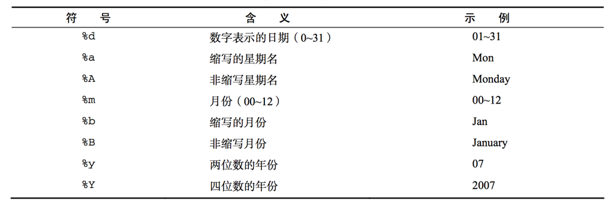

```r
format(Sys.Date(),format="%m %d %Y")
```

```
## [1] "03 27 2018"
```

```r
format(Sys.Date(),format="%m %d %y")
```

```
## [1] "03 27 18"
```

```r
format(Sys.Date(),format="%B %b %Y")
```

```
## [1] "March Mar 2018"
```

## 日期函数

```r
(today <- Sys.Date())
```

```
## [1] "2018-03-27"
```

```r
dif <- today - real_dates
class(dif)
```

```
## [1] "difftime"
```

```r
difftime(today,real_dates,units="week")
```

```
## Time differences in weeks
## [1] 330.1429 276.5714 242.7143 163.1429
```

```r
as.character(today)
```

```
## [1] "2018-03-27"
```

## lubridate包

```r
library(lubridate)
today()  # date
```

```
## [1] "2018-03-27"
```

```r
now() # date-time (time 可以用hms包)
```

```
## [1] "2018-03-27 17:12:29 CST"
```

```r
as_date(now())
```

```
## [1] "2018-03-27"
```

```r
as_datetime(today())
```

```
## [1] "2018-03-27 UTC"
```

## lubridate包

转换为日期-时间

```r
ymd("2017-01-31")
```

```
## [1] "2017-01-31"
```

```r
mdy("January 31st, 2017")
```

```
## [1] "2017-01-31"
```

```r
dmy("31-Jan-2017")
```

```
## [1] "2017-01-31"
```

```r
ymd(20170131)
```

```
## [1] "2017-01-31"
```

```r
ymd_hms("2017-01-31 20:11:59")
```

```
## [1] "2017-01-31 20:11:59 UTC"
```

```r
mdy_hm("01/31/2017 08:01")
```

```
## [1] "2017-01-31 08:01:00 UTC"
```

```r
ymd(20170131, tz = "UTC")
```

```
## [1] "2017-01-31 UTC"
```

## 组合成分为时间

```r
library(nycflights13)
flights_dt <- flights %>%
   filter(!is.na(dep_time), !is.na(arr_time)) %>%
  mutate(
    departure = make_datetime(year, month, day, hour, minute),
    dep_time =  make_datetime(year, month, day, dep_time %/% 100, dep_time %% 100))
flights_dt  %>%
  select(year, month, day, hour, minute,departure,dep_time)
```

```
## # A tibble: 328,063 x 7
##     year month   day  hour minute departure           dep_time
##    <int> <int> <int> <dbl>  <dbl> <dttm>              <dttm>
##  1  2013     1     1    5.    15. 2013-01-01 05:15:00 2013-01-01 05:17:00
##  2  2013     1     1    5.    29. 2013-01-01 05:29:00 2013-01-01 05:33:00
##  3  2013     1     1    5.    40. 2013-01-01 05:40:00 2013-01-01 05:42:00
##  4  2013     1     1    5.    45. 2013-01-01 05:45:00 2013-01-01 05:44:00
##  5  2013     1     1    6.     0. 2013-01-01 06:00:00 2013-01-01 05:54:00
##  6  2013     1     1    5.    58. 2013-01-01 05:58:00 2013-01-01 05:54:00
##  7  2013     1     1    6.     0. 2013-01-01 06:00:00 2013-01-01 05:55:00
##  8  2013     1     1    6.     0. 2013-01-01 06:00:00 2013-01-01 05:57:00
##  9  2013     1     1    6.     0. 2013-01-01 06:00:00 2013-01-01 05:57:00
## 10  2013     1     1    6.     0. 2013-01-01 06:00:00 2013-01-01 05:58:00
## # ... with 328,053 more rows
```

## 例子:一天内每十分钟航班数

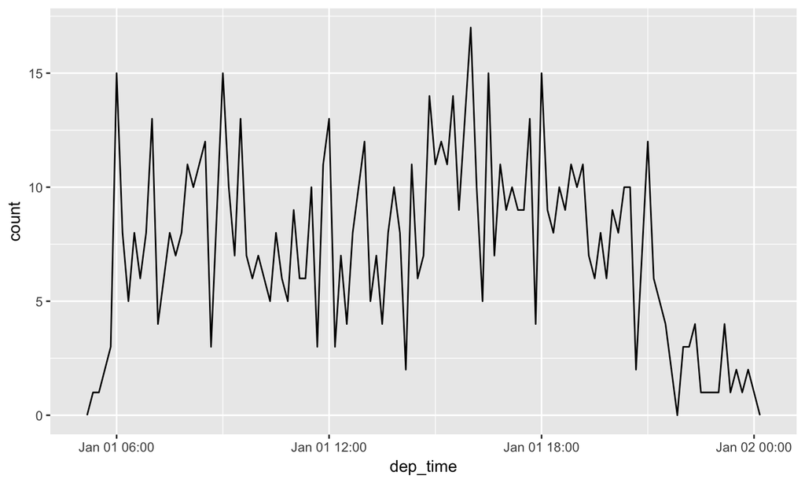

```r
flights_dt %>%
  filter(dep_time < ymd(20130102)) %>%
  ggplot(aes(dep_time)) +
  geom_freqpoly(binwidth = 600) # 600 s = 10 minutes
```

## 获取成分

```r
datetime <- ymd_hms("2016-07-08 12:34:56")

year(datetime)
```

```
## [1] 2016
```

```r
month(datetime)
```

```
## [1] 7
```

```r
mday(datetime)
```

```
## [1] 8
```

```r
yday(datetime)
```

```
## [1] 190
```

```r
wday(datetime)
```

```
## [1] 6
```

```r
month(datetime, label = TRUE)
```

```
## [1] Jul
## 12 Levels: Jan < Feb < Mar < Apr < May < Jun < Jul < Aug < Sep < ... < Dec
```

```r
wday(datetime, label = TRUE, abbr = FALSE)
```

```
## [1] Friday
## 7 Levels: Sunday < Monday < Tuesday < Wednesday < Thursday < ... < Saturday
```

## 例子：一个星期每天航班数

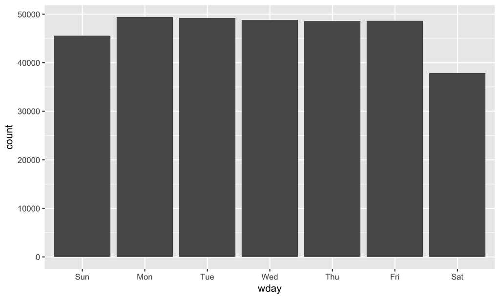

```r
flights_dt %>%
  mutate(wday = wday(dep_time, label = TRUE)) %>%
  ggplot(aes(x = wday)) +
    geom_bar()
```

## 修改时间成分

```r
(datetime <- ymd_hms("2016-07-08 12:34:56"))
```

```
## [1] "2016-07-08 12:34:56 UTC"
```

```r
year(datetime) <- 2020
datetime
```

```
## [1] "2020-07-08 12:34:56 UTC"
```

```r
month(datetime) <- 01
datetime
```

```
## [1] "2020-01-08 12:34:56 UTC"
```

```r
hour(datetime) <- hour(datetime) + 1
datetime
```

```
## [1] "2020-01-08 13:34:56 UTC"
```

```r
ymd("2015-02-01") %>%
  update(year=2017,hour = 400)
```

```
## [1] "2017-02-17 16:00:00 UTC"
```

## 例子：将日期部分统一以关注日内时间分布

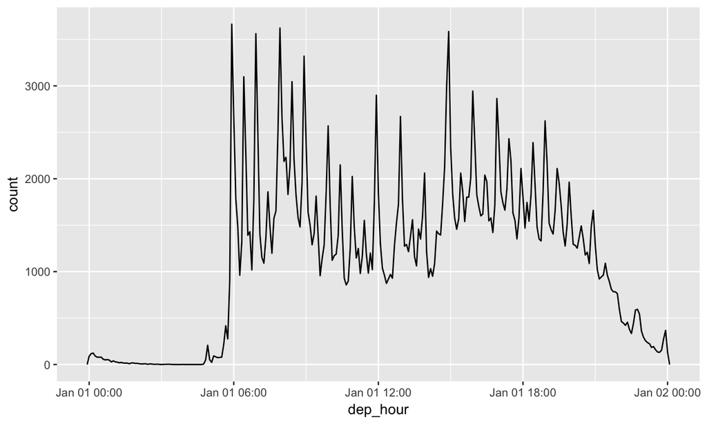

```r
flights_dt %>%
  mutate(dep_hour = update(dep_time, yday = 1)) %>%
  ggplot(aes(dep_hour)) +
    geom_freqpoly(binwidth = 300) ## 每5分钟
```

## 日期函数

```r
# SPSS格式的时间数据处理
library(foreign)
cred <- read.spss("../xample final/credit_card.sav",to.data.frame =TRUE)
# spss日期转换R格式
# SPSS的日期以1582年10月14日为基准
cred$dob <- cred$dob++ISOdate(1582,10,14)
cred$card_date <- cred$card_date++ISOdate(1582,10,14)
```

## 其他日期相关问题（自学）

- 间隔
  - durations, which represent an exact number of seconds.
  - periods, which represent human units like weeks and months.
  - intervals, which represent a starting and ending point.
- 时区